# House Price Modeling in King County, WA

Steve Su, Pierson Wodarz

7/20/2020

## Introduction

In this study we will investigate sales data for houses in King County, WA (which includes Seattle) sold between May 2014 and May 2015. In particular, we are concerned with the sales prices of these homes and identifying the factors contributing to the sale price such that it becomes possible to predict the price of a given house.

This is useful to the authors as it can be used for personal decisions when moving to Seattle and purchasing a home. Additionally, it allows the authors to validate or compare to other listed estimates and prices, such as the list price of the home or estimates like the Zillow Zestimate or Redfin Estimate. For example, [Zillow’s CEO sold his home for less than 40% of the Zillow estimate](https://www.geekwire.com/2016/zillow-ceo-spencer-rascoff-sold-home-40-less-zestimate-1-75-million/), underscoring the importance of accurate predictions and the potential for improvement in existing systems. Finally, even if the numerical values for the predictors are no longer valid, this study will allow the authors to identify an appropriate form of the model that can be trained on more recent data (house prices may have risen over the previous years, for example).

The data for this study was sourced from [Kaggle](https://www.kaggle.com/swathiachath/kc-housesales-data). The data set contains records of house sales in King County, WA, with a total of 21,597 observations and 21 variables. As our goal is to model the price of houses, we will treat the price variable as our response, and the other variables as potential predictors. These variables include numeric data types such as number of bathrooms/bedrooms, square footage of living space/basement, and number of floors. Additionally, the predictor variables include categorical variables such as zipcode and waterfront property or not.

In this study we will utilize several regression methods for modeling the data.

## Methods

### Loading data

First, we load the data stored in `kc_house_data.csv` for the values of the predictors and the response.

```r
library(readr)
house_data = read_csv("kc_house_data.csv")
```

### Data Pre-Processing

Upon receiving the data we removed several columns which we believed were not benefical as predictors. These were the date, id number and views. Since we wanted the model to be general, not influenced by the specific dates in this data set, we decided to remove the date column. For obvious reasons we removed id number as this just used for tracking within the data set. We also removed views because there was a discrepancy with its description. The variable Views was described as the number of showings the house had, however its value is capped at four. It’s unusual for houses to have no more than four showings. Because of this confusion we dropped it as one of the predictors.

```r
house_data = house_data[ ,-c(1, 2, 10)] # Remove irrelevant variables (including id, date, view)
```

When importing the data set, all variables imported as either a float or integer. In order to denote which ones we wanted to be categorical we coerced them to be factor variables. These included zipcode and waterfront. Lastly, we checked the data set for missing values, but found none.

```r
house_data$waterfront = as.factor(house_data$waterfront)
house_data$zipcode = as.factor(house_data$zipcode)
```

Before any model building was done we performed an exploratory data analysis (described in detail below) to help summarize the data to provide insights which could be used during the model building phase of the project. By constructing box plots of the predictors we made a decision to convert the yr_renovated predictor from a numeric data type to a boolean. The original data had 0 if the property was not renovated and year of renovation (e.g. 2015) if the property was renovated. This meant the data represented both boolean information (renovated/not-renovated) and numeric information (year renovated). It was not valid to use the numeric values, as 0 is not a real year for renovation, so we converted the entire variable to a boolean data type.

```r
house_data$yr_renovated = ifelse(house_data$yr_renovated == 0, 0, 1) #change yr_rennovated to boolean data type
house_data$yr_renovated = as.factor(house_data$yr_renovated)
```

### Initial Review of Data

A pairs plot was constructed to view the relation of each predictor to the repsonse (price) and observe any obvious relationships. For example, we noticed that some predictors, such as bedrooms, seemed to have a positive exponential relation with the response. In contrast, sqft_lot seemed to have a negative exponential relation. The lat and long variables appeared to have some form of a polynomial relation. Lastly, several predictors, such as grade and sqft_living, showed somewhat of a linear relation to the response. This insight will be helpful when deciding how a predictor might be transformed when constructing the model.

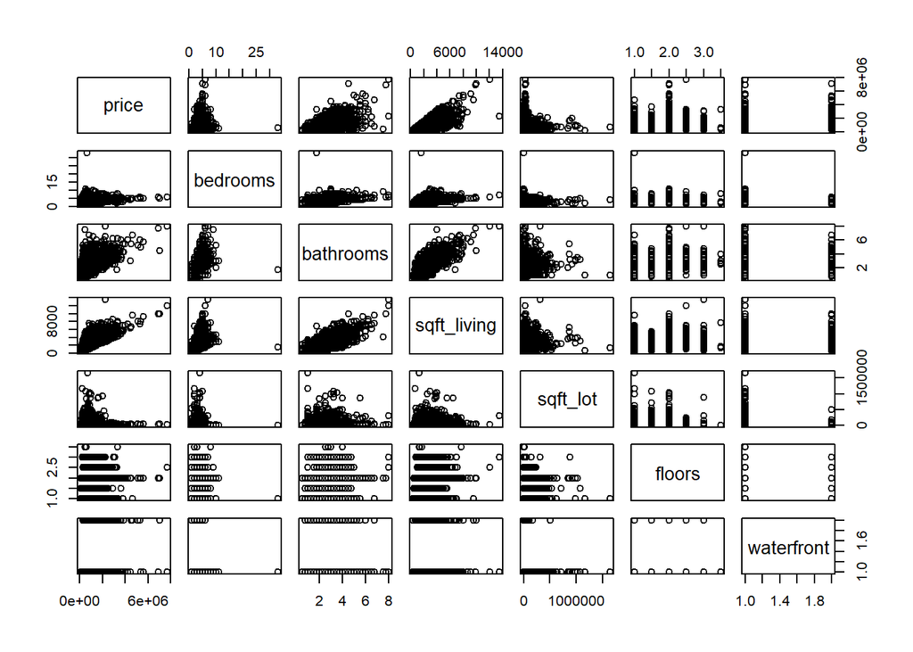

```r
pairs(house_data[, 1:7])
```

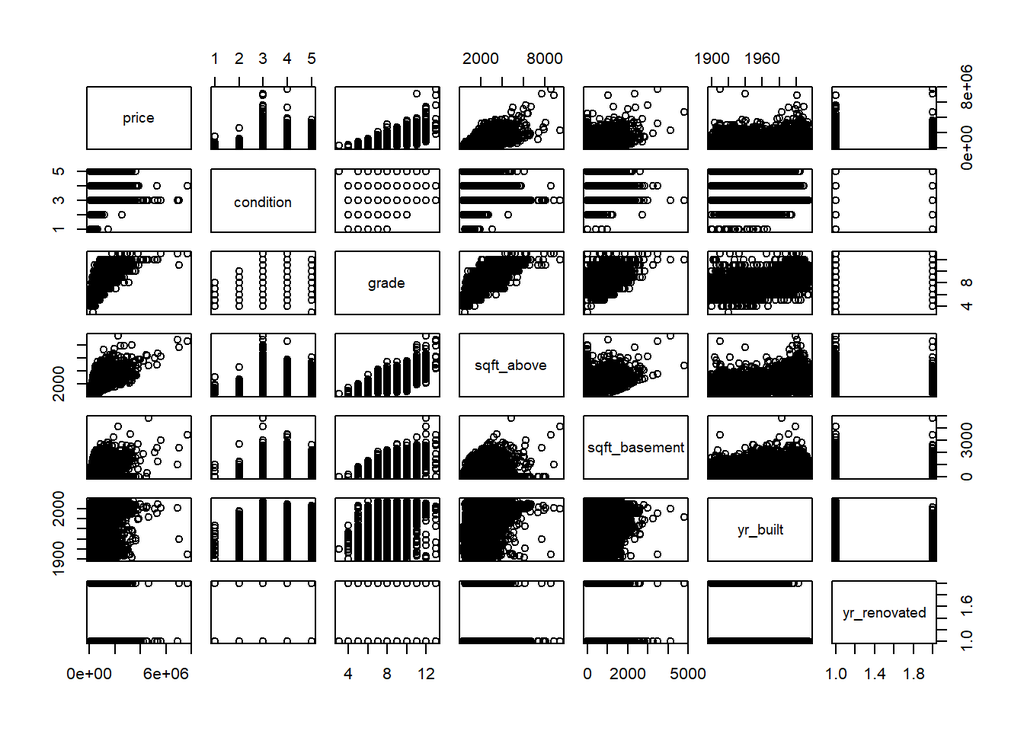

```r
pairs(house_data[ , c(1,8:13)])
```

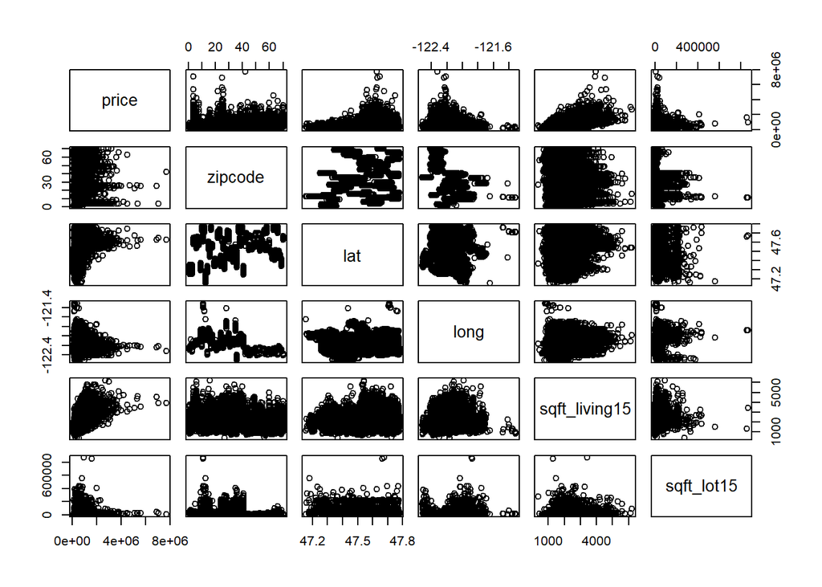

```r
pairs(house_data[ , c(1,14:18)])
```

Additionally, a correlation table of all the predictors was made to get a sense of colinearity. Some of the higher correlations found, > 0.70, were between the variables sqft_living:sqft_living15 and sqft_lot:sqft_lot15. The difference between the two is sqft_living is the original square footage before 2015 and sqft_living15 is the square footage after 2015. If there was an increase after 2015 this meant that there was square footage added to the house due to an expansion. A majority of the houses do not have increases in square footage so there is high colinearity. One could argue that the pre 2015 square footage data could be left out since it is already coded in the sqft_living15 variable. However, we decided to leave it in and see how backward selection might treat them. While the variable sqft_basement did not have a high correlation number we found that it had a near-zero partial correlation coefficient with the effects of the other variables removed. We discovered this when an error was flagged when fitting the model using the lm() function. There was a singularity error with the sqft_basement variable. To further investigate, we fit a model using sqft_basement as the response with the remaining predictors and got a result of $R^2 = 1$. This demonstrates that the variation of price that is unexplained by all variables but sqft_basement shows very little correlation with the variation of sqft_basement that is not explained by the other variables. Thus, adding sqft_basement to the model would likely be of little benefit and we removed it.

```r
sqft_basement_fit = lm(sqft_basement ~ . - price, data = house_data)
price_fit = lm(price ~ . -sqft_basement, data = house_data)
cor(resid(sqft_basement_fit), resid(price_fit))
```

```
## [1] 0.0005511
```

```r
summary(sqft_basement_fit)$r.squared
```

```
## [1] 1
```

```r
# Remove sqft_basement due to low correlation and R^2 = 1
house_data = house_data[ ,-c(11)]
```

```r
round(cor(house_data[, -c(7,12,13)]),2)
```

```
##               price bedrooms bathrooms sqft_living sqft_lot floors condition
## price          1.00     0.31      0.53        0.70     0.09   0.26      0.04
## bedrooms       0.31     1.00      0.51        0.58     0.03   0.18      0.03
## bathrooms      0.53     0.51      1.00        0.76     0.09   0.50     -0.13
## sqft_living    0.70     0.58      0.76        1.00     0.17   0.35     -0.06
## sqft_lot       0.09     0.03      0.09        0.17     1.00   0.00     -0.01
## floors         0.26     0.18      0.50        0.35     0.00   1.00     -0.26
## condition      0.04     0.03     -0.13       -0.06    -0.01  -0.26      1.00
## grade          0.67     0.36      0.67        0.76     0.11   0.46     -0.15
## sqft_above     0.61     0.48      0.69        0.88     0.18   0.52     -0.16
## yr_built       0.05     0.16      0.51        0.32     0.05   0.49     -0.36
## lat            0.31    -0.01      0.02        0.05    -0.09   0.05     -0.02
## long           0.02     0.13      0.22        0.24     0.23   0.13     -0.11
## sqft_living15  0.59     0.39      0.57        0.76     0.14   0.28     -0.09
## sqft_lot15     0.08     0.03      0.09        0.18     0.72  -0.01      0.00
##               grade sqft_above yr_built   lat  long sqft_living15 sqft_lot15
## price          0.67       0.61     0.05  0.31  0.02          0.59       0.08
## bedrooms       0.36       0.48     0.16 -0.01  0.13          0.39       0.03
## bathrooms      0.67       0.69     0.51  0.02  0.22          0.57       0.09
## sqft_living    0.76       0.88     0.32  0.05  0.24          0.76       0.18
## sqft_lot       0.11       0.18     0.05 -0.09  0.23          0.14       0.72
## floors         0.46       0.52     0.49  0.05  0.13          0.28      -0.01
## condition     -0.15      -0.16    -0.36 -0.02 -0.11         -0.09       0.00
## grade          1.00       0.76     0.45  0.11  0.20          0.71       0.12
## sqft_above     0.76       1.00     0.42  0.00  0.34          0.73       0.20
## yr_built       0.45       0.42     1.00 -0.15  0.41          0.33       0.07
## lat            0.11       0.00    -0.15  1.00 -0.14          0.05      -0.09
## long           0.20       0.34     0.41 -0.14  1.00          0.34       0.26
## sqft_living15  0.71       0.73     0.33  0.05  0.34          1.00       0.18
## sqft_lot15     0.12       0.20     0.07 -0.09  0.26          0.18       1.00
```

### Model Building

We randomly split the data into a training data set (80% of the data) and a testing data set (remaining 20%) for use in selecting between different models.

```r
set.seed(19940627)
house_idx = sample(nrow(house_data), as.integer(nrow(house_data) * 0.80))
house_trn = house_data[house_idx, ]
house_tst = house_data[-house_idx, ]
```

We write a function that will return various metrics to be used for selecting/differentiating between models as we progress through our model building.

```r
sel_crit = function(model, data) {
  n = nrow(data)
  LOOCV_RMSE = sqrt(mean((resid(model) / (1 - hatvalues(model))) ^ 2))
  RMSE =  sqrt((1 / n) * sum((predict(model, newdata = data) - data$price) ^ 2))
  adjR2 = summary(model)$adj.r.squared
  AIC = extractAIC(model)[2]
  num_p = length(coef(model)) - 1
  data.frame(LOOCV_RMSE = LOOCV_RMSE, RMSE = RMSE, adjR2 = adjR2, AIC = AIC, num_p = num_p)
}
```

```r
calcStats = function(model, data_tst, name) {
  data = data_tst
  n = nrow(data)
  len = length(model)
  LOOCV_RMSE = rep(0, len)
  RMSE = rep(0, len)
  adjR2 = rep(0, len)
  AIC = rep(0, len)
  num_p = rep(0, len)


  for(i in 1:len) {
    LOOCV_RMSE[i] = sqrt(mean((resid(model[[i]]) / (1 - hatvalues(model[[i]]))) ^ 2))
    RMSE[i] =  sqrt((1 / n) * sum((predict(model[[i]], newdata = data) - data$price) ^ 2))
    adjR2[i] = summary(model[[i]])$adj.r.squared
    AIC[i] = extractAIC(model[[i]])[2]
    num_p[i] = length(coef(model[[i]])) - 1
    name[i] = paste(toString(i), name[i])
  }
  #df = data.frame(LOOCV = LOOCV_RMSE, RMSE_test = RMSE, AdjR2 = adjR2, Aic = AIC, predictors = num_p)
  df = data.frame(RMSE_test = RMSE, AdjR2 = adjR2, Aic = AIC, predictors = num_p)
  rownames(df) = name
  df
}
```

First, we create an additive model to provide ourselves a baseline from which to improve. Additionally, we perform backwards AIC selection to reduce the number of predictors.

```r
add_mod = lm(price ~ ., data = house_trn)
sel_crit(add_mod, house_tst)
```

```
##   LOOCV_RMSE   RMSE  adjR2    AIC num_p
## 1     167980 157148 0.7959 415585    84
```

```r
add_mod_aic = step(add_mod, direction = "backward", trace = 0)
sel_crit(add_mod_aic, house_tst)
```

```
##   LOOCV_RMSE   RMSE  adjR2    AIC num_p
## 1     167980 157148 0.7959 415585    84
```

We note that backwards AIC selection has no improvement, and was not particularly useful. But we established a “baseline” RMSE of 1.571510^{5}.

Next, we try a 2-way interactive model.

```r
int_mod = lm(price ~ (.) * (.), data = house_trn)
sel_crit(int_mod, house_tst)
```

```
##   LOOCV_RMSE   RMSE  adjR2    AIC num_p
## 1        Inf 115076 0.9187 400740  1224
```

This model has a much lower RMSE (1.150810^{5}) compared to the additive model. However, the number of parameters is very high.

We note that most of these parameters are from (appropriately) treating zipcode as a factor. We continue by trying to fit a 3-way interaction model, but we must remove zipcode from the interaction (keeping it as a predictor) because our computers cannot process this many predictors.

```r
int_mod_3way = lm(price ~ (. -zipcode ) * (. -zipcode ) * (. -zipcode ) + zipcode, data = house_trn)
sel_crit(int_mod_3way, house_tst)
```

```
##   LOOCV_RMSE   RMSE  adjR2    AIC num_p
## 1     188624 150526 0.9004 403737   644
```

As observed, the criteria for selection are worse in 3-way interaction, so we are likely overfitting the data in this case, so we return to 2-way interaction.

Again we note that for 2-way interaction most of these parameters are from (properly) treating zipcode as a factor. So we investigate what happens if we remove zipcode as an interaction parameter (but still have zipcode as a predictor).

```r
int_mod_no_zipint = lm(price ~ (. -zipcode) * (. -zipcode) + zipcode, data = house_trn)
sel_crit((int_mod_no_zipint), house_tst)
```

```
##   LOOCV_RMSE   RMSE  adjR2    AIC num_p
## 1     134201 130352 0.8768 406973   189
```

We see test RMSE increases (which is undesirable) but we have ~1/6 the number of predictors, which is preferred for understanding and ease-of-consumption of the model.

Additionally, from our correlation table, we observe that there are quite a few parameters that are highly correlated (namely sqft_living with sqft_above/sqft_living15 and sqft_lot with sqft_lot15) so we explore reducing to a single predictor for each correlated set.

```r
mod_rmv_cor = lm(price ~ (. -zipcode - sqft_above  -sqft_lot15 -sqft_living15) * (. -zipcode - sqft_above  -sqft_lot15 -sqft_living15) + zipcode, data = house_trn)
sel_crit((mod_rmv_cor), house_tst)
```

```
##   LOOCV_RMSE   RMSE  adjR2    AIC num_p
## 1     137120 134431 0.8692 407966   147
```

```r
mod_rmv_cor = lm(price ~ (. -zipcode - sqft_above  -sqft_lot15 ) * (. -zipcode - sqft_above  -sqft_lot15) + zipcode, data = house_trn)
sel_crit((mod_rmv_cor), house_tst)
```

```
##   LOOCV_RMSE   RMSE adjR2    AIC num_p
## 1     134997 131483 0.874 407322   160
```

From the pairs graphs, we can see that some terms appear to have a polynomial, exponential, or logarithmic relationship with price, so we investigate adding all polynomial terms.

```r
poly_int_mod = lm(price ~ (. -zipcode -sqft_above  -sqft_lot15) * (. -zipcode -sqft_above  -sqft_lot15) + zipcode + polym(bedrooms, bathrooms, sqft_living, sqft_lot, floors, condition, grade, sqft_above, yr_built, lat, long, sqft_living15, sqft_lot15, degree = 2),  data = house_trn)
sel_crit((poly_int_mod), house_tst)
```

```
##   LOOCV_RMSE    RMSE  adjR2    AIC num_p
## 1     133144 1032303 0.8784 406749   264
```

Since this had no improvement, and vastly overfit the data, we attempt to model specific polynomial terms that appear to have a polynomial, exponential, or logarithmic relationship with price from the pairs graph. Specifically:

- lat: apparent polynomial relationship with price
- bedrooms: apparent polynomial or exponential relationship with price (more like a gaussian peak)
- sqft_lot: apparent inverse relationship with price
- condition: apparent log relationship with price

```r
poly_int_mod = lm(price ~ (. -zipcode -sqft_above  -sqft_lot15) * (. -zipcode -sqft_above  -sqft_lot15) + zipcode + I(lat ^ 2) +  I(bedrooms ^ 2)  + exp(bedrooms) + I(sqft_lot ^ -1) + log(condition),  data = house_trn)
sel_crit((poly_int_mod), house_tst)
```

```
##   LOOCV_RMSE   RMSE  adjR2    AIC num_p
## 1        Inf 131206 0.8761 407041   165
```

We observe the single variable t-test for some of these terms and remove those with low coefficients and high p-values. Namely, exp(bedrooms), I(bedrooms ^ 2) and log(condition) and observe the minimal affect on test RMSE, indicating they do not need to be included in the model.

```r
poly_int_mod_red = lm(price ~ (. -zipcode -sqft_above  -sqft_lot15) * (. -zipcode -sqft_above  -sqft_lot15) + zipcode + I(lat ^ 2) + I(sqft_lot ^ -1),  data = house_trn)
sel_crit((poly_int_mod_red), house_tst)
```

```
##   LOOCV_RMSE   RMSE  adjR2    AIC num_p
## 1     133809 131255 0.8761 407037   162
```

```r
full_int_poly = lm(price ~ (.) * (.) + I(lat ^ 2) + I(sqft_lot ^ -1),  data = house_trn)
sel_crit(full_int_poly, house_tst)
```

```
##   LOOCV_RMSE   RMSE  adjR2    AIC num_p
## 1        Inf 115174 0.9188 400714  1226
```

Returning to the reduced interactive polynomial model (without zipcode interactions), we perform backwards AIC to arrive at a final model.

```r
poly_int_aic = step(poly_int_mod_red, direction = "backward", trace = 0)
sel_crit(poly_int_aic, house_tst)
```

```
##   LOOCV_RMSE   RMSE  adjR2    AIC num_p
## 1     133210 131341 0.8762 407009   142
```

We see that LOOCV_RMSE, adjR2, AIC, and num_p are marginally better while test RMSE is marginally worse.

Ultimately then, we have two models to compare, one with a low RMSE, but high number of parameters (int_mod - an interaction model with zipcode interactions) and one with a higher RMSE, but lower number of parameters (poly_int_aic - an interaction and polynomial model without zipcode interactions).

```r
sel_crit(poly_int_aic, house_tst)
```

```
##   LOOCV_RMSE   RMSE  adjR2    AIC num_p
## 1     133210 131341 0.8762 407009   142
```

```r
sel_crit(int_mod, house_tst)
```

```
##   LOOCV_RMSE   RMSE  adjR2    AIC num_p
## 1        Inf 115076 0.9187 400740  1224
```

## Results

**Table of Statistical Metrics of Selected Models**

|  | RMSE_test | AdjR2 | Aic | predictors |
| --- | --- | --- | --- | --- |
| 1 add_mod | 157148 | 0.7959 | 415585 | 84 |
| 2 int_mod | 115076 | 0.9187 | 400740 | 1224 |
| 3 int_mod_no_zipint | 130352 | 0.8768 | 406973 | 189 |
| 4 poly_int_mod_red | 131255 | 0.8761 | 407037 | 162 |
| 5 poly_int_aic | 131341 | 0.8762 | 407009 | 142 |

**QQplots and Fitted vs Residual plots: poly_int_aic, int_mod**

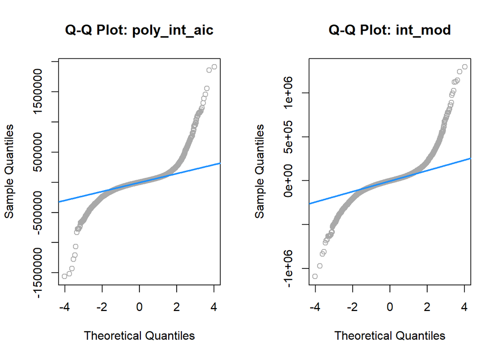

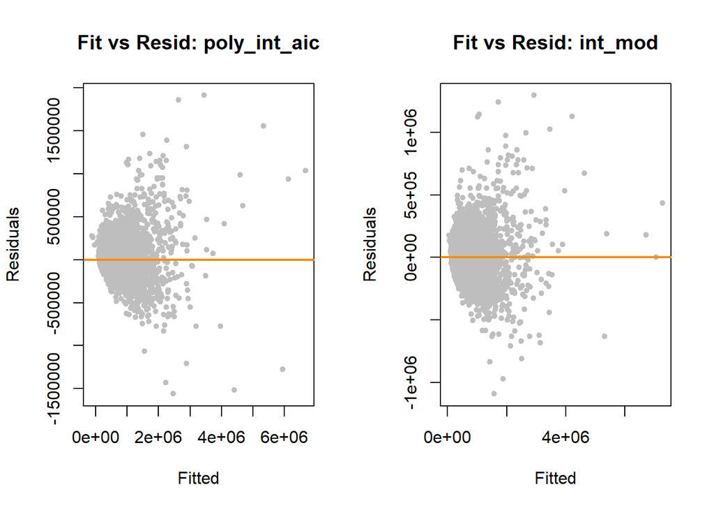

**Table of p-values Shapiro/Bptest of Select Models**

|  | shapiro | bptest |
| --- | --- | --- |
| 1 add_mod | 0e+00 | 7.567e-64 |
| 2 int_mod | 0e+00 | 1.380e-57 |
| 3 int_mod_no_zipint | 0e+00 | 1.397e-59 |
| 4 poly_int_mod_red | 0e+00 | 7.116e-61 |
| 5 poly_int_aic | 0e+00 | 8.172e-61 |

From the plot above, we see that neither model (poly_int_aic and int_mod) follows the normality or equal variance of the LINE assumptions. The Q-Q plot has obvious deviations at its tails and the residual plots appear to diverge as the fitted value increases. In fact all of our selected models do not satisfy the LINE asumptions. The p-values of the Breusch Pagan test and the Shapiro test are presented above and are extremely low.

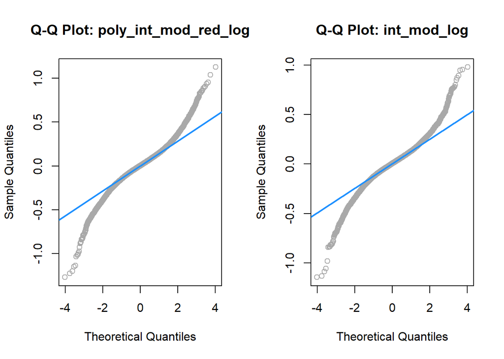

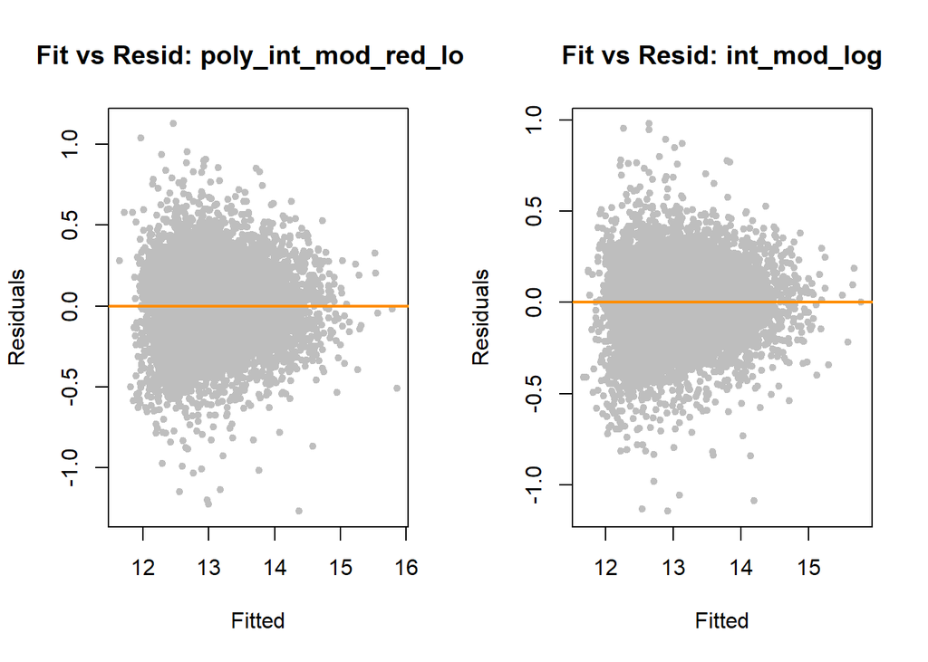

**Table of p-values Shapiro/Bptest before and after log transformation of response**

[output not shown]

In an attempt to meet the LINE assumptions, we performed a log transformation of the response variable. It showed some improvement in terms of increasing the p-values on the BreuschPagan and Shapiro tests (shown above) but they are still tremendously low. Upon visual inspection of the plots above, the Q-Q plot does not appear to have any improvement but the residuals plot looks slightly more random. In general, log transformation of the response variable helped to increase the Bptest p-value from 1e-50 to 1e-30 if this can be considered an improvement with such a low p-value.

We attempted to achieve the LINE assumptions by additonal log and polynomial tranformations on the predictors but did not succeed. As a result we wanted to know if it were possible to achieve a LINE model if we removed all the high cook distance observations where > 4/n. This exercise was just to see if it was possible and not to generate a model for use.

**QQplots and Fitted vs Residual plots: high Cook distance removed (exercise only)**

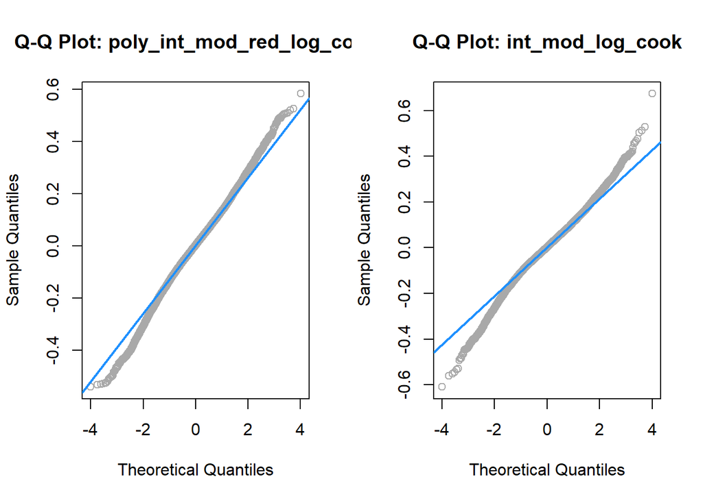

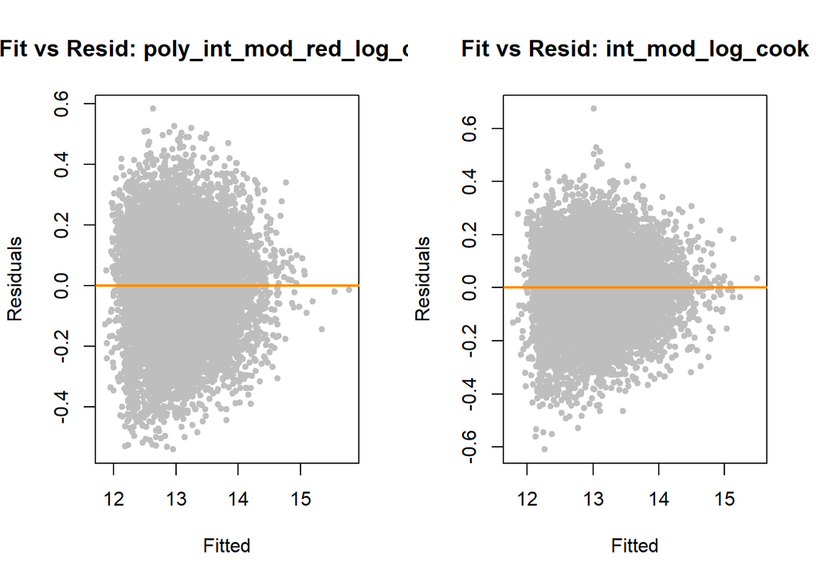

**Table of p-values Shapiro/Bptest with high Cook distance removed (exercise only)**

|  | shapiro | bptest |
| --- | --- | --- |
| 1 poly_int_mod_red_log_cook | 4.992e-225 | 3.986e-11 |
| 2 int_mod_log_cook | 1.271e-67 | 6.006e-16 |

Visually, there is quite an improvement with the Q-Qplot and noticeable improvement with the fitted vs residuals plot. However the p-values are still very low indicating that they are not passing the assumptions of normality of the residuals and constant variance. Even with throwing out all the high Cook distance observations we cannot achieve the LINE assumptions.

## Discussion

if i were to make a sweeping statement about trying to interpret this model, there seems to be a lot of interactions tied to the bedroom, bathroom and sqftliving. How’s that for our interpetation? of course zip code by itself is important, most are significant. we should put this long summary in the appendix. I thought we should not bother with the log transform price models as our chosen model for simiplicity but it’s up to you.

```r
summary(poly_int_aic)
```

```
##
## Call:
## lm(formula = price ~ bedrooms + bathrooms + sqft_living + sqft_lot +
##     floors + waterfront + condition + grade + yr_built + yr_renovated +
##     lat + long + sqft_living15 + zipcode + I(lat^2) + I(sqft_lot^-1) +
##     bedrooms:bathrooms + bedrooms:sqft_living + bedrooms:sqft_lot +
##     bedrooms:floors + bedrooms:waterfront + bedrooms:yr_built +
##     bedrooms:long + bathrooms:sqft_living + bathrooms:sqft_lot +
##     bathrooms:floors + bathrooms:waterfront + bathrooms:yr_built +
##     bathrooms:yr_renovated + bathrooms:lat + bathrooms:long +
##     bathrooms:sqft_living15 + sqft_living:sqft_lot + sqft_living:floors +
##     sqft_living:waterfront + sqft_living:condition + sqft_living:grade +
##     sqft_living:yr_built + sqft_living:yr_renovated + sqft_living:lat +
##     sqft_living:long + sqft_living:sqft_living15 + sqft_lot:floors +
##     sqft_lot:grade + sqft_lot:yr_built + sqft_lot:lat + sqft_lot:long +
##     sqft_lot:sqft_living15 + floors:lat + floors:sqft_living15 +
##     waterfront:condition + waterfront:grade + waterfront:yr_built +
##     waterfront:yr_renovated + waterfront:lat + waterfront:long +
##     waterfront:sqft_living15 + condition:grade + condition:yr_built +
##     condition:yr_renovated + condition:lat + condition:sqft_living15 +
##     grade:yr_renovated + grade:lat + grade:long + grade:sqft_living15 +
##     yr_built:yr_renovated + yr_built:long + yr_built:sqft_living15 +
##     yr_renovated:lat + yr_renovated:long + yr_renovated:sqft_living15 +
##     lat:sqft_living15 + long:sqft_living15, data = house_trn)
##
## Residuals:
##      Min       1Q   Median       3Q      Max
## -1559945   -52249     -881    47222  1908518
##
## Coefficients:
##                              Estimate Std. Error t value Pr(>|t|)
## (Intercept)                 -4.75e+09   4.43e+08  -10.71  < 2e-16 ***
## bedrooms                     5.01e+06   1.60e+06    3.13  0.00175 **
## bathrooms                   -7.02e+06   2.62e+06   -2.68  0.00734 **
## sqft_living                 -1.93e+04   2.64e+03   -7.30  3.0e-13 ***
## sqft_lot                     3.17e+01   2.31e+01    1.37  0.17042
## floors                       2.29e+06   8.68e+05    2.64  0.00821 **
## waterfront1                  6.51e+07   1.89e+07    3.44  0.00057 ***
## condition                    2.31e+06   6.71e+05    3.44  0.00057 ***
## grade                       -1.92e+07   1.55e+06  -12.40  < 2e-16 ***
```

[output cut: 125 more lines]

```
## grade:sqft_living15          5.38e+00   2.57e+00    2.10  0.03617 *
## yr_built:yr_renovated1      -8.13e+02   2.44e+02   -3.34  0.00085 ***
## yr_built:long                6.08e+03   4.55e+02   13.36  < 2e-16 ***
## yr_built:sqft_living15      -5.77e-01   1.17e-01   -4.92  8.9e-07 ***
## yr_renovated1:lat           -8.80e+04   4.44e+04   -1.98  0.04756 *
## yr_renovated1:long           1.92e+05   4.50e+04    4.28  1.9e-05 ***
## yr_renovated1:sqft_living15  4.91e+01   1.14e+01    4.31  1.6e-05 ***
## lat:sqft_living15            6.65e+01   2.12e+01    3.14  0.00168 **
## long:sqft_living15          -8.67e+01   2.17e+01   -4.00  6.4e-05 ***
## ---
## Signif. codes:  0 '***' 0.001 '**' 0.01 '*' 0.05 '.' 0.1 ' ' 1
##
## Residual standard error: 130000 on 17134 degrees of freedom
## Multiple R-squared:  0.877,  Adjusted R-squared:  0.876
## F-statistic:  862 on 142 and 17134 DF,  p-value: <2e-16
```